# Assignment5_7 K11777873 - Ahmed Hagy

```python
import random
import numpy as np
import pandas as pd
import matplotlib.pyplot as plt
from time import time
from sklearn import svm
from sklearn import preprocessing
from sklearn.preprocessing import Imputer
from sklearn.model_selection import GridSearchCV , ParameterGrid, StratifiedShuffleSplit
from sklearn.ensemble import RandomForestClassifier


random.seed(149)
```

```python
def loaddata(URL, col_names):
    return pd.read_csv(URL, names=col_names, na_values="?")

def fill_na(data, strategy='mean'):
    columns = data.columns
    imp = Imputer(missing_values='NaN', strategy=strategy, axis=0)
    imp.fit(data)
    data = imp.transform(data)
    data = pd.DataFrame(data=data, columns=columns)
    return data
```

```python
def train_svm(data, target, costs, gammas, n_jobs=4):
    parameters = [{'kernel': ['rbf'], 'C': costs, 'gamma': gammas},
                 {'kernel': ['linear'], 'C': costs}]
    svr = svm.SVC()
    grid = GridSearchCV(svr, parameters, cv = 10, n_jobs=n_jobs)

    bef = time()
    grid.fit(data, target)
    print "Best Params: ", grid.best_params_
    print "Best Score: ", grid.best_score_
    print 'Total time elapsed: %f minutes' % ((time() - bef) / 60)
    return grid
```

```python
def train_randomforests_cv(data, target, n_jobs=4):
    param_grid = {'n_estimators': [10, 100, 1000, 10000]}

    cv = StratifiedShuffleSplit(n_splits=10, test_size=0.10)

    grid = GridSearchCV(RandomForestClassifier(n_jobs=n_jobs), param_grid=param_grid, cv=10, verbose=1, n_jobs=n_jobs)
    bef = time()
    grid.fit(data, target)
    print "Best Params: ", grid.best_params_
    print "Best Score: ", grid.best_score_
    return grid

def train_randomforests_oob(data, target, n_jobs=4):
    param_grid = {'n_estimators': [10, 100, 1000, 10000]}
    clf = RandomForestClassifier(n_jobs=n_jobs, verbose=1, oob_score=True)
    oob_scores = []
    best_score = 0
    best_grid = None
    bef = time()
    for g in ParameterGrid(param_grid):
        clf.set_params(**g)
        clf.fit(data,target)
        oob_scores += [clf.oob_score_]
        if clf.oob_score_ > best_score:
            best_grid = g
            best_score = clf.oob_score_

    print "Best OOB: %0.5f" % best_score
    print "Best Params:", best_grid
    print 'Total time elapsed: %f minutes' % ((time() - bef) / 60)
    return oob_scores

def get_feature_importance(data, target, n_trees, n_jobs=4):
    clf = RandomForestClassifier(n_jobs=n_jobs, verbose=1, n_estimators=n_trees, oob_score=True)
    clf.fit(data, target)
    return clf
```

```python
def plot_svm_linear(grid, costs, gammas):
    plt.clf()
    plt.rcParams['figure.figsize'] = (20,15)
    plt.plot(range(len(costs)), grid.cv_results_['mean_test_score'][-len(costs):], '-bo', alpha=0.5)
    plt.xticks(range(len(costs)), np.round(costs, decimals=3))
    plt.xlabel("Cost", fontsize=20)
    plt.ylabel("Score", fontsize=20)
    plt.tick_params(axis='both', which='major', labelsize=15)
    plt.title("SVM Linear-Kernel", fontsize=25)
    plt.show()

def plot_svm_rbf(grid, costs, gammas):
    plt.clf()
    plt.rcParams['figure.figsize'] = (20,15)
    for i in xrange(len(gammas)):
        points = [grid.cv_results_['mean_test_score'][len(gammas)*ind + i] for ind in xrange(len(costs))]
        if i == np.int(np.argwhere(np.array(gammas) == grid.best_params_['gamma'])):
            plt.plot(range(len(costs)), points, '-ko', alpha=0.5)
        else:
            plt.plot(range(len(costs)), points, alpha=0.5)
    plt.xticks(range(len(costs)), np.round(costs, decimals=3))

    plt_legend = plt.legend(np.round(gammas, decimals=3), title='gamma value', fontsize=15)
    plt_legend.get_title().set_fontsize('15')

    plt.xlabel("Cost", fontsize=20)
    plt.ylabel("Score", fontsize=20)
    plt.tick_params(axis='both', which='major', labelsize=15)
    plt.title("SVM RBF-Kernel", fontsize=25)
    plt.show()

def plot_randomforests(values, n_trees, title):
    plt.clf()
    plt.rcParams['figure.figsize'] = (20,15)
    plt.plot(range(len(n_trees)), values, '-bo', alpha=0.8)
    plt.xticks(range(len(n_trees)), n_trees)
    plt.xlabel("n_trees", fontsize=20)
    plt.ylabel("Score", fontsize=20)
    plt.tick_params(axis='both', which='major', labelsize=15)
    plt.title(title, fontsize=25)
    plt.show()

def plot_randomforests(values, n_trees, title):
    plt.clf()
    plt.rcParams['figure.figsize'] = (20,15)
    plt.plot(range(len(n_trees)), values, '-bo', alpha=0.8)
    plt.xticks(range(len(n_trees)), n_trees)
    plt.xlabel("n_trees", fontsize=20)
    plt.ylabel("Score", fontsize=20)
    plt.tick_params(axis='both', which='major', labelsize=15)
    plt.title(title, fontsize=25)
    plt.show()

def plot_oob_vs_cv(values1, values2, n_trees, title, legend):
    plt.clf()
    plt.rcParams['figure.figsize'] = (20,15)
    plt.plot(range(len(n_trees)), values1, '-bo', range(len(n_trees)), values2, '-ro', alpha=0.8)
    plt.xticks(range(len(n_trees)), n_trees)
    plt.xlabel("n_trees", fontsize=20)
    plt.ylabel("Score", fontsize=20)
    plt.tick_params(axis='both', which='major', labelsize=15)
    plt.title(title, fontsize=25)
    plt_legend = plt.legend(legend, fontsize=15)
    plt_legend.get_title().set_fontsize('15')
    plt.show()
```

**Breast Cancer Dataset**

**SVM with rbf and linear kernels**

```python
col_names = ["ID", "ClumpThickness", "UniformityOfCellSize", "UniformityOfCellShape",
                 "MarginalAdhesion", "SingleEpithelialCellSize", "BareNuclei", "BlandChromatin",
                 "NormalNucleoli", "Mitoses", "Class"]
URL = "https://archive.ics.uci.edu/ml/machine-learning-databases/breast-cancer-wisconsin/breast-cancer-wisconsin.data"
costs = [2**i for i in np.arange(-8, 5, 1.0)]
gammas = [2**i for i in np.arange(-8, 3, 1.0)]

breast_cancer = loaddata(URL, col_names)
breast_cancer = breast_cancer.dropna(0)
```

Without filling the NAs:

```python
bc_svm = train_svm(breast_cancer.drop(['ID', 'Class'], 1), breast_cancer["Class"], costs, gammas)
```

```
Best Params:  {'kernel': 'rbf', 'C': 0.5, 'gamma': 0.015625}
Best Score:  0.972181551977
Total time elapsed: 0.340409 minutes
```

After filling the NAs with the mean of the column:

```python
breast_cancer = loaddata(URL, col_names)
breast_cancer = fill_na(breast_cancer)
bc_svm = train_svm(breast_cancer.drop(['ID', 'Class'], 1), breast_cancer["Class"], costs, gammas)
```

```
Best Params:  {'kernel': 'rbf', 'C': 0.25, 'gamma': 0.00390625}
Best Score:  0.969957081545
Total time elapsed: 0.311658 minutes
```

we can see that the score actually dropped after handling the NAs, indicating that our handling wasn't proper. Probably the method we used "mean" is not the best here. Let's take a look on the 'BareNuclei' Column:

```python
breast_cancer.BareNuclei.unique()
```

```
array([  1.        ,  10.        ,   2.        ,   4.        ,
         3.        ,   9.        ,   7.        ,   3.54465593,
         5.        ,   8.        ,   6.        ])
```

We can clearly see the column contains discrete values between 1 and 10 and the 3.5 is the mean we just added. We can interpret that 'BareNuclei' only takes discrete values and the decimal number we added messed up the column data. A more proper way would've been the 'mode' since we just take the most repeated entry from the column and won't introduce new values.

```python
breast_cancer = loaddata(URL, col_names)
breast_cancer = fill_na(breast_cancer, strategy='most_frequent')
bc_svm = train_svm(breast_cancer.drop(['ID', 'Class'], 1), breast_cancer["Class"], costs, gammas)
```

```
Best Params:  {'kernel': 'rbf', 'C': 0.25, 'gamma': 0.00390625}
Best Score:  0.969957081545
Total time elapsed: 0.306057 minutes
```

**PS: I knew this wasn't required and probably not graded, but just wanted to try :)**

```python
breast_cancer = loaddata(URL, col_names)
breast_cancer = breast_cancer.dropna(0)
bc_svm = train_svm(breast_cancer.drop(['ID', 'Class'], 1), breast_cancer["Class"], costs, gammas)
```

```
Best Params:  {'kernel': 'rbf', 'C': 0.5, 'gamma': 0.015625}
Best Score:  0.972181551977
Total time elapsed: 0.310082 minutes
```

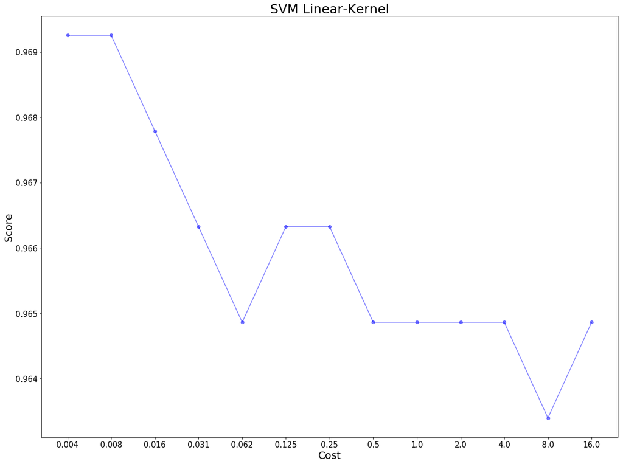

```python
plot_svm_linear(bc_svm, costs, gammas)
```

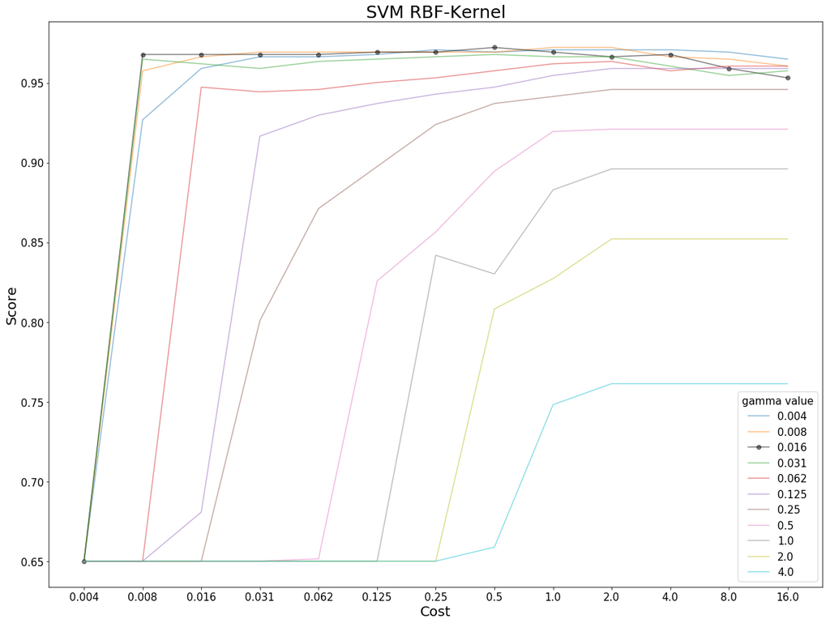

```python
plot_svm_rbf(bc_svm, costs, gammas)
```

**Random Forests**

```python
bc_rf_cv = train_randomforests_cv(breast_cancer.drop(['ID', 'Class'], 1), breast_cancer["Class"], 4)
```

```
Fitting 10 folds for each of 4 candidates, totalling 40 fits
```

```
[Parallel(n_jobs=4)]: Done  40 out of  40 | elapsed:  6.5min finished
```

```
Best Params:  {'n_estimators': 10000}
Best Score:  0.970717423133
```

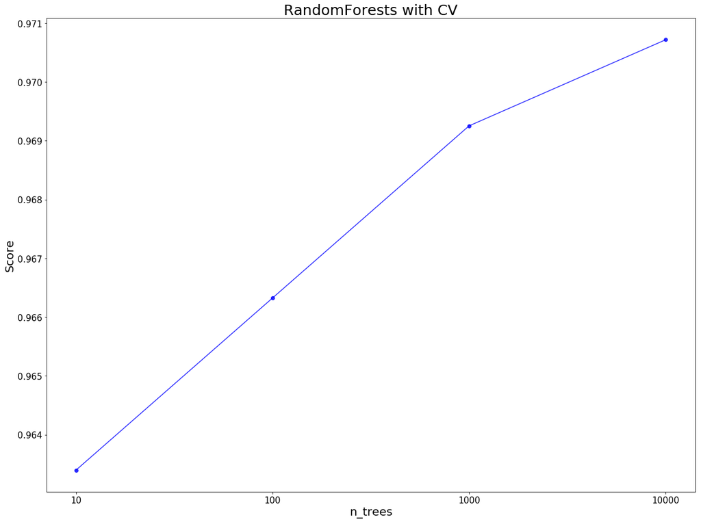

```python
plot_randomforests(bc_rf_cv.cv_results_['mean_test_score'], bc_rf_cv.param_grid['n_estimators'], "RandomForests with CV")
```

```python
bc_rf_oob = train_randomforests_oob(breast_cancer.drop(['ID', 'Class'], 1), breast_cancer["Class"], 4)
```

[output not shown]

```
Best OOB: 0.97511
Best Params: {'n_estimators': 1000}
Total time elapsed: 1.349287 minutes
```

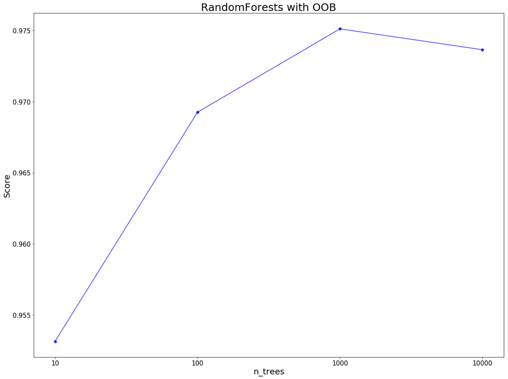

```python
plot_randomforests(bc_rf_oob, [10, 100, 1000, 10000], "RandomForests with OOB")
```

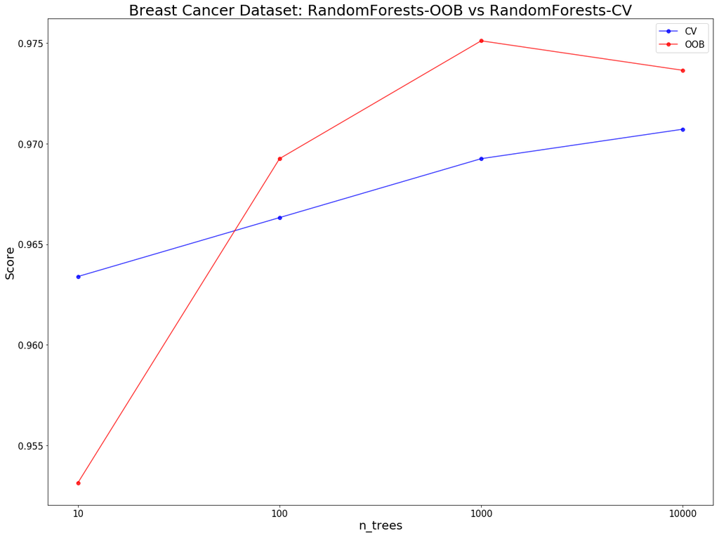

```python
plot_oob_vs_cv(bc_rf_cv.cv_results_['mean_test_score'], bc_rf_oob, [10, 100, 1000, 10000], 'Breast Cancer Dataset: RandomForests-OOB vs RandomForests-CV', ['CV', 'OOB'])
```

**Performance Comparison**

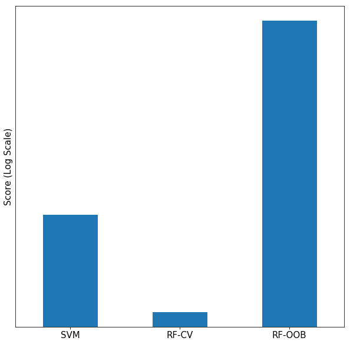

```
           Score
SVM     0.972182
RF-CV   0.970717
RF-OOB  0.975110
```

```python
plt.clf()
plt.rcParams['figure.figsize'] = (10, 10)
accuracies = [0.972181551977, 0.970717423133, 0.97511]
bc_performance_df = pd.DataFrame(accuracies, columns=["Score"], index=["SVM", "RF-CV", "RF-OOB"])
ax = bc_performance_df.plot.bar(legend=False)
plt.xticks(rotation=0)
plt.yscale('log')
plt.ylabel("Score (Log Scale)", fontsize=15)
plt.tick_params(axis='both', which='major', labelsize=15)
plt.show()
print bc_performance_df
```

**Feautre Importance**

```python
bc_feature_importance = get_feature_importance(breast_cancer.drop(['ID', 'Class'], 1), breast_cancer["Class"], 1000)
```

```
[Parallel(n_jobs=4)]: Done  42 tasks      | elapsed:    0.1s
[Parallel(n_jobs=4)]: Done 192 tasks      | elapsed:    0.3s
[Parallel(n_jobs=4)]: Done 442 tasks      | elapsed:    0.8s
[Parallel(n_jobs=4)]: Done 792 tasks      | elapsed:    1.4s
[Parallel(n_jobs=4)]: Done 1000 out of 1000 | elapsed:    1.7s finished
```

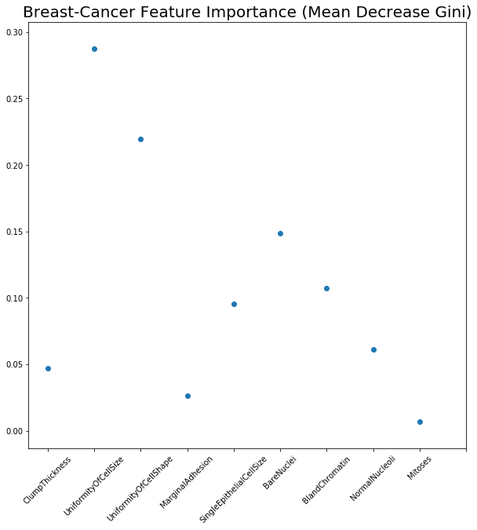

```python
plt.clf()
plt.rcParams['figure.figsize'] = (15, 7)
plt.scatter(range(len(breast_cancer.columns) - 2), bc_feature_importance.feature_importances_)
plt.xticks(range(len(breast_cancer.columns) -1), breast_cancer.drop(['ID', 'Class'], 1).columns, rotation=45)
plt.title("Breast-Cancer Feature Importance (Mean Decrease Gini)", fontsize=20)
plt.tick_params(axis='both', which='major', labelsize=10)
plt.show()
```

**Wine Dataset**

```python
col_names = ["Class", "Alcohol", "Malic acid", "Ash", "Alcalinity of ash ", "Magnesium",
             "Total phenols", "Flavanoids", "Nonflavanoid phenols", "Proanthocyanins",
             "Color intensity", "Hue", "OD280/OD315 of diluted wines", "Proline"]
URL = "https://archive.ics.uci.edu/ml/machine-learning-databases/wine/wine.data"

costs = [2**i for i in np.arange(-8, 5, 1.0)]
gammas = [2**i for i in np.arange(-8, 3, 1.0)]

wine = loaddata(URL, col_names)
wine = fill_na(wine)
wine["Class"] = pd.to_numeric(wine["Class"], downcast='integer')
wine_target = wine["Class"]
```

**SVM**

```python
wine_scaled = preprocessing.scale(wine)
wine_scaled = pd.DataFrame(wine_scaled, columns=col_names)
wine_svm = train_svm(wine_scaled.drop('Class', 1), wine_target, costs, gammas)
```

```
Best Params:  {'kernel': 'rbf', 'C': 0.25, 'gamma': 0.03125}
Best Score:  0.988764044944
Total time elapsed: 0.123351 minutes
```

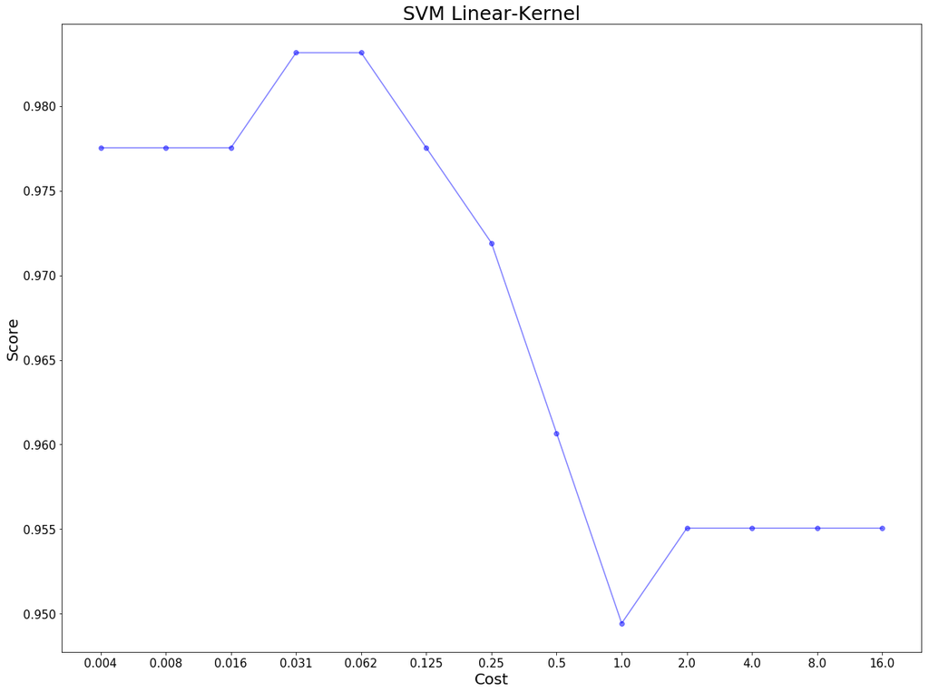

```python
plot_svm_linear(wine_svm, costs, gammas)
```

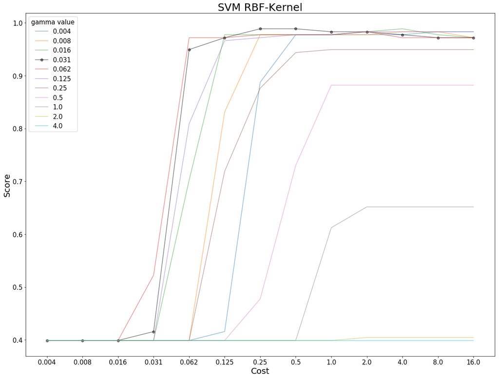

```python
plot_svm_rbf(wine_svm, costs, gammas)
```

**Random Forests**

```python
wine_rf_cv = train_randomforests_cv(wine.drop('Class', 1), wine_target, 4)
```

```
Fitting 10 folds for each of 4 candidates, totalling 40 fits
```

```
[Parallel(n_jobs=4)]: Done  40 out of  40 | elapsed: 10.9min finished
```

```
Best Params:  {'n_estimators': 1000}
Best Score:  0.983146067416
```

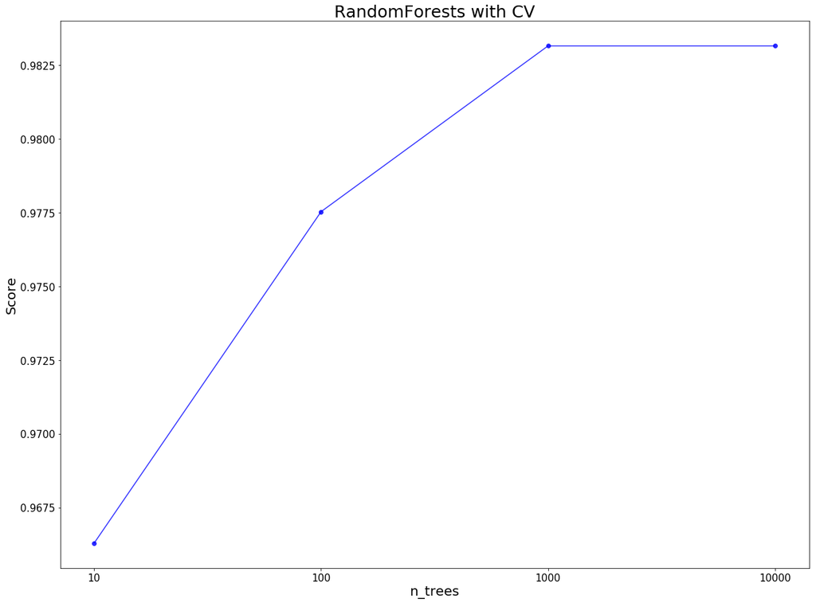

```python
plot_randomforests(wine_rf_cv.cv_results_['mean_test_score'], wine_rf_cv.param_grid['n_estimators'], "RandomForests with CV")
```

```python
wine_rf_oob = train_randomforests_oob(wine.drop(['Class'], 1), wine_target, 4)
```

[output not shown]

```
Best OOB: 0.99438
Best Params: {'n_estimators': 100}
Total time elapsed: 2.174180 minutes
```

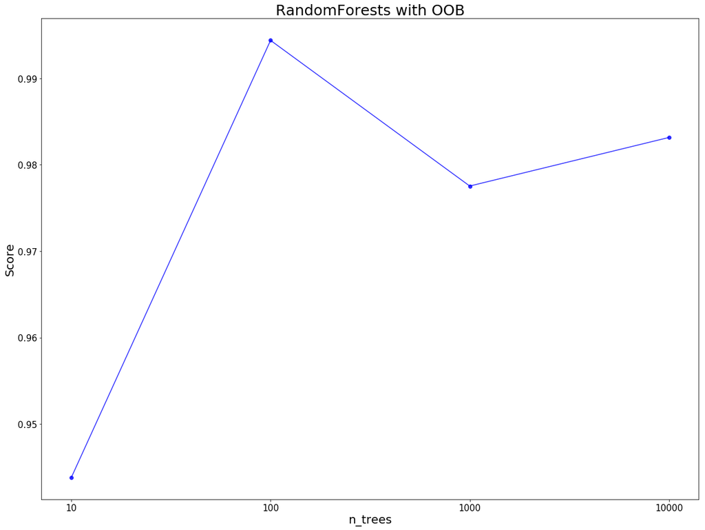

```python
plot_randomforests(wine_rf_oob, [10, 100, 1000, 10000], "RandomForests with OOB")
```

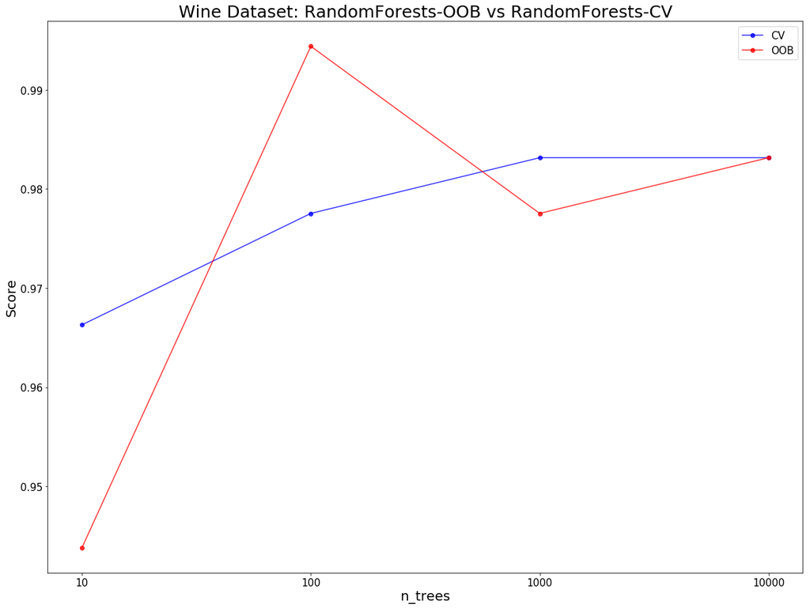

```python
plot_oob_vs_cv(wine_rf_cv.cv_results_['mean_test_score'], wine_rf_oob, [10, 100, 1000, 10000], 'Wine Dataset: RandomForests-OOB vs RandomForests-CV', ['CV', 'OOB'])
```

**Performance Comparison**

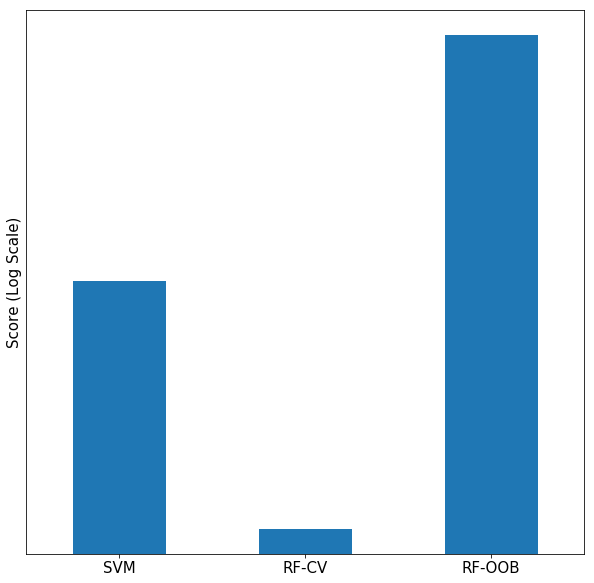

```
           Score
SVM     0.988764
RF-CV   0.983146
RF-OOB  0.994380
```

```python
plt.clf()
plt.rcParams['figure.figsize'] = (10, 10)
accuracies = [0.988764044944, 0.983146067416, 0.99438]
wine_performance_df = pd.DataFrame(accuracies, columns=["Score"], index=["SVM", "RF-CV", "RF-OOB"])
ax = wine_performance_df.plot.bar(legend=False)
plt.xticks(rotation=0)
plt.yscale('log')
plt.ylabel("Score (Log Scale)", fontsize=15)
plt.tick_params(axis='both', which='major', labelsize=15)
plt.show()
print wine_performance_df
```

**Feautre Importance**

```python
wine_feature_importance = get_feature_importance(wine.drop(['Class'], 1), wine_target, 4, 100)
```

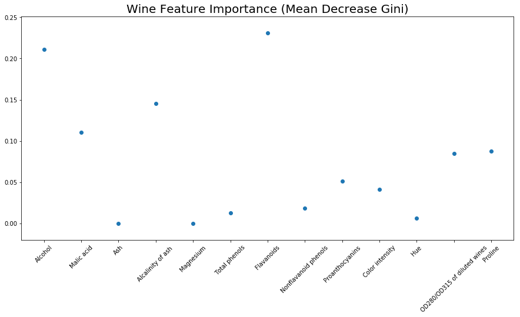

```python
plt.clf()
plt.rcParams['figure.figsize'] = (15, 7)
# print wine.drop(['Class'], 1).columns
plt.scatter(range(len(wine.columns) -1), wine_feature_importance.feature_importances_)
plt.xticks(range(len(wine.columns) -1), wine.drop(['Class'], 1).columns, rotation=45)
plt.title("Wine Feature Importance (Mean Decrease Gini)", fontsize=20)
plt.tick_params(axis='both', which='major', labelsize=10)
plt.show()
```

As seen from above "Alcohol" and "Flavanoids" are the most important features and would contribute the most in the Accuracy of the model. However, I noticed that re running the RandomForest.fit() with the same no. of trees yields different values for the feature importance and couldn't know why... maybe because we didn't specify the 'random_state' arg of the RF classifier?

**Sequence One hot encoded**

```python
def one_hot_encoding(data):
    """
    Transforms the dataframe into a one_hot_encoded dataframe.

    :param data: dataframe
    :return:     datframe with 300 more columns
    """
    letters = ["A", "C", "D", "E", "F", "G", "H", "I", "K", "L", "M", "N", "P", "Q", "R", "S", "T", "V", "W", "Y"]
    col_names = []
    seq_len = 15
    # generating the column names "0_A", "1_A" .... for evey position of the 15
    for index in range(seq_len):
        col_names += [str(idx) + "_" + letter for idx, letter in zip([index]*20, letters)]

    # adding those columns to the dataframe with default value 0
    data = data.join(pd.DataFrame([[0]*seq_len*20], index=data.index, columns=col_names))
    # iterating over the rows and fixing the column values
    for i in xrange(len(data)):
        seq = data.loc[i, 'Seq']
        for index in xrange(len(seq)):
            data.loc[i, str(index) + "_" + seq[index]] = 1
    return data

sequence = loaddata('Sequences_train.csv', ['Seq', 'Class'])
sequence = one_hot_encoding(sequence)
```

**SVM**

Training the svm with the best parameters we acquired from last assignment:

```python
best_cost = 2.0
best_gamma = 0.0625
seq_svm = train_svm(sequence.drop(['Seq', 'Class'], 1), sequence['Class'], [best_cost], [best_gamma])
```

```
Best Params:  {'kernel': 'rbf', 'C': 2.0, 'gamma': 0.0625}
Best Score:  0.892
Total time elapsed: 0.469328 minutes
```

**Random Forests**

```python
seq_rf_cv = train_randomforests_cv(sequence.drop(['Seq', 'Class'], 1), sequence['Class'], 4)
```

```
Fitting 10 folds for each of 4 candidates, totalling 40 fits
```

```
[Parallel(n_jobs=4)]: Done  40 out of  40 | elapsed: 11.7min finished
```

```
Best Params:  {'n_estimators': 1000}
Best Score:  0.884
```

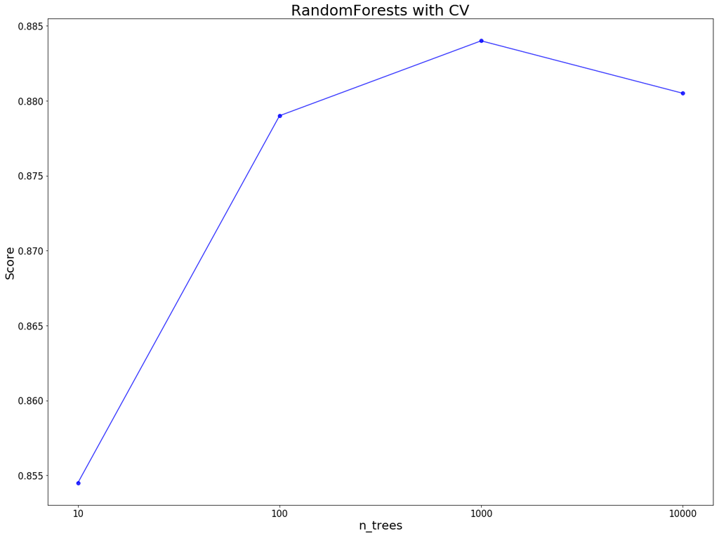

```python
plot_randomforests(seq_rf_cv.cv_results_['mean_test_score'], seq_rf_cv.param_grid['n_estimators'], "RandomForests with CV")
```

```python
seq_rf_oob = train_randomforests_oob(sequence.drop(['Seq', 'Class'], 1), sequence['Class'], 4)
```

[output not shown]

```
Best OOB: 0.88900
Best Params: {'n_estimators': 10000}
Total time elapsed: 3.409643 minutes
```

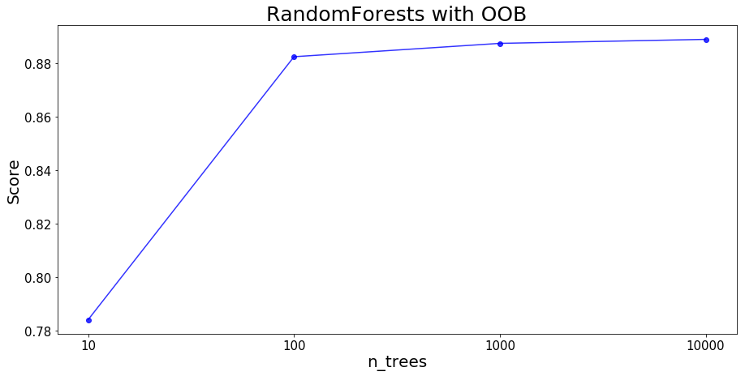

```python
plot_randomforests(seq_rf_oob, [10, 100, 1000, 10000], "RandomForests with OOB")
```

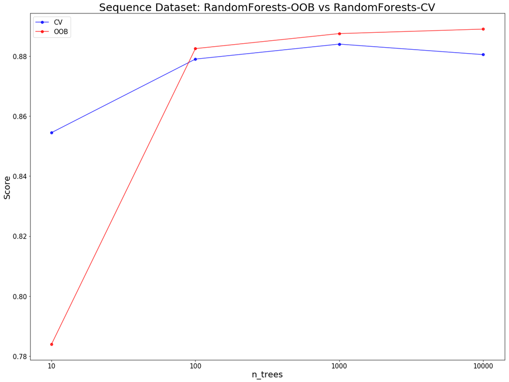

```python
plot_oob_vs_cv(seq_rf_cv.cv_results_['mean_test_score'], seq_rf_oob, [10, 100, 1000, 10000], 'Sequence Dataset: RandomForests-OOB vs RandomForests-CV', ['CV', 'OOB'])
```

**Performance Comparison**

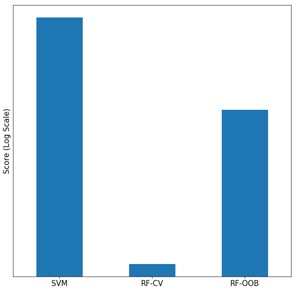

```
        Score
SVM     0.892
RF-CV   0.884
RF-OOB  0.889
```

```python
plt.clf()
plt.rcParams['figure.figsize'] = (10, 10)
accuracies = [seq_svm.best_score_, seq_rf_cv.best_score_, max(seq_rf_oob)]
seq_performance_df = pd.DataFrame(accuracies, columns=["Score"], index=["SVM", "RF-CV", "RF-OOB"])
ax = seq_performance_df.plot.bar(legend=False)
plt.xticks(rotation=0)
plt.yscale('log')
plt.ylabel("Score (Log Scale)", fontsize=15)
plt.tick_params(axis='both', which='major', labelsize=15)
plt.show()
print seq_performance_df
```

**Feautre Importance**

```python
seq_feature_importance = get_feature_importance(sequence.drop(['Seq', 'Class'], 1), sequence['Class'], 1000)
```

```
[Parallel(n_jobs=4)]: Done  42 tasks      | elapsed:    0.1s
[Parallel(n_jobs=4)]: Done 192 tasks      | elapsed:    0.9s
[Parallel(n_jobs=4)]: Done 442 tasks      | elapsed:    1.9s
[Parallel(n_jobs=4)]: Done 792 tasks      | elapsed:    3.2s
[Parallel(n_jobs=4)]: Done 1000 out of 1000 | elapsed:    4.4s finished
```

```python
seq_feature_importance_array = np.array(seq_feature_importance.feature_importances_)
indices = np.argsort(seq_feature_importance_array)
x_ticks = seq_feature_importance_array[indices[-30:]]
```

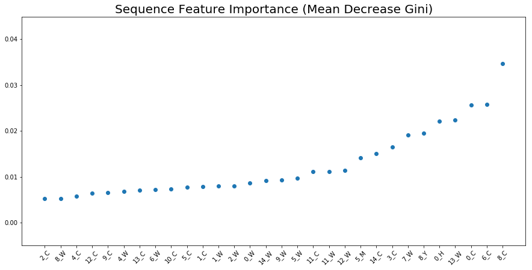

```python
plt.clf()
plt.rcParams['figure.figsize'] = (15, 7)
plt.scatter(range(len(x_ticks)), x_ticks)
plt.xticks(range(len(x_ticks)), sequence.drop(['Class', 'Seq'], 1).columns[indices], rotation=45)
plt.title("Sequence Feature Importance (Mean Decrease Gini)", fontsize=20)
plt.tick_params(axis='both', which='major', labelsize=10)
plt.show()
```